# Source Data Used in this App

Below are brief descriptions of the source datasets used in this app. For more details, please refer to the linked original paper.

# bulk RNAseq Dataset

## General Information

**Tabula Muris Senis** (bulk Dataset)  
https://tabula-muris-senis.sf.czbiohub.org

**Description**  
Tabula Muris Senis is a comprehensive transcriptomic cell atlas of mice covering a wide range of ages. The atlas includes both single-cell RNA-seq and bulk RNA-seq data. In this app, only bulk RNA-seq data are used.

**Link to the Original Paper**  
Schaum N, Lehallier B, Hahn O, et al. Ageing hallmarks exhibit organ-specific temporal signatures. Nature. 2020;583(7817):596-602.  
[doi:10.1038/s41586-020-2499-y](https://doi.org/10.1038/s41586-020-2499-y)

## Sample Information

**Mouse Strain**  
C57BL/6JN

**Age/Sex Group Composition**

- male mice (n = 4; aged 1, 3, 6, 9, 12, 15, 18, 21, 24 and 27 months)
- female mice (n = 2; aged 1, 3, 6, 9, 12, 15, 18 and 21 months)

*Note: The numbers above indicate the number of mice; actual sample counts per tissue may be lower due to quality filtering.*

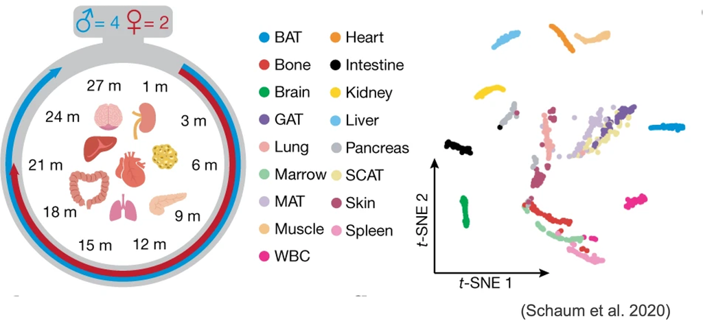

**Measurement Platform**  
Illumina NovaSeq 6000 (Mus musculus)

## Original Data Repository

Gene Expression Omnibus (GSE132040)

# Proteomic Dataset

## General Information

**Description**  
Proteomic data were retrieved from the paper by Keele et al. (2023). In this study, the authors performed discovery-based proteomics using tandem mass tags (TMTs) in 10 tissues from 20 C57BL/6J mice, including both sexes and two age groups (8 and 18 months).

**Link to the Original Paper**  
Keele GR, Zhang JG, Szpyt J, et al. Global and tissue-specific aging effects on murine proteomes. Cell Rep. 2023;42(7):112715.  
[doi:10.1016/j.celrep.2023.112715](https://doi.org/10.1016/j.celrep.2023.112715)

## Sample Information

**Mouse Strain**  
C57BL/6J

**Age/Sex Group Composition**

- 8-month male (N=5)
- 8-month female (N=5)
- 18-month male (N=5)
- 18-month female (N=5)

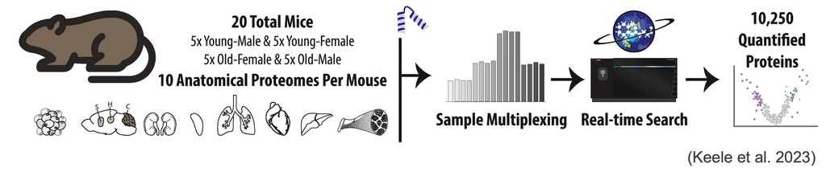

**Measurement Platform**  
Tandem mass tags (TMTs)

## Original Data Repository

Fig Share ([DOI link](https://doi.org/10.6084/m9.figshare.19765849))

# Metabolomic Dataset

## General Information

**Description**  
Metabolomic data were retrieved from the paper by Jankowski et al. (2025). In this study, the authors performed both metabolomics and stable isotope tracing on young (3–6 months) and aged (+21 months) C57BL/6J mice. In this app, only the metabolomic data are used.

**Link to the Original Paper**  
Jankowski CSR, Samarah LZ, MacArthur MR, et al. Aged mice exhibit widespread metabolic changes but preserved major fluxes. Cell Metab. 2025;37(11):2280-2294.e4.  
[doi:10.1016/j.cmet.2025.09.009](https://doi.org/10.1016/j.cmet.2025.09.009)

## Sample Information

**Mouse Strain**  
C57BL/6J

**Age/Sex Group Composition**  
Each group (young male, young female, aged male, aged female) consisted of 8–10 samples per tissue (Approximately 70% of tissue–sex–age groups had N = 10).

**Tissue**  
15 tissues (including serum) were analyzed:

- **Serum**
- **Brain**
- **Eye**
- **Diaphragm**
- **Heart**
- **Jejunum**
- **Kidney**
- **Liver**
- **Lung**
- **Pancreas**
- **Spleen**
- **Colon**
- **Quadriceps**
- **Soleus**
- **Skin (Ear)**

**Measurement Platform**  
Hydrophilic interaction chromatography (HILIC) coupled with a quadrupole-orbitrap mass spectrometer (QExactive Plus, Exploris 240, or Exploris 480)

## Original Data Source

Raw data were obtained from the Supplementary Table (Table S6) of the original publication.  
Individual metabolite data are also available at the R/Shiny app developed by the authors:  
https://agingmet.princeton.edu/ (last accessed 2025-12-08)